# Notebook

### Web Information Retrieval and Data Mining - Assignment 3

```
Student: Wientjes, Manon (1398903)
```

#### Answer 1.1, Baseline (4p)

- Dense network, at least 3 layers, shaped like a pyramid
  - Last layer: 10 nodes, sigmoid.
  - Loss: categorical cross-entropy. Metric: accuracy
- No preprocessing, regularization. Get at least 70% accuracy.
- Explain design decisions. Discuss performance.
  - Does it overfit (large/growing gap between loss and val_loss)?

[output not shown]

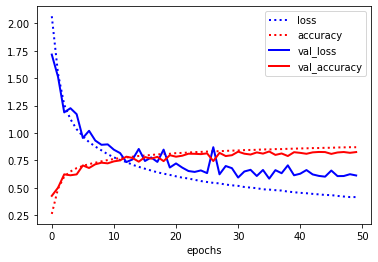

```
Model: "sequential_6"
_________________________________________________________________
Layer (type)                 Output Shape              Param #
=================================================================
reshape_6 (Reshape)          (None, 3072)              0
_________________________________________________________________
dense_24 (Dense)             (None, 256)               786688
_________________________________________________________________
dense_25 (Dense)             (None, 128)               32896
_________________________________________________________________
dense_26 (Dense)             (None, 32)                4128
_________________________________________________________________
dense_27 (Dense)             (None, 10)                330
=================================================================
Total params: 824,042
Trainable params: 824,042
Non-trainable params: 0
_________________________________________________________________
None
def build_model_1_1():
    model = models.Sequential()
    model.add(layers.Reshape((3072,), input_shape=(32,32,3)))
    model.add(layers.Dense(256, activation='relu'))
    model.add(layers.Dense(128, activation='relu'))
    model.add(layers.Dense(32, activation='relu'))
    model.add(layers.Dense(10, activation='softmax'))
    model.compile(optimizer='sgd',
                  loss='categorical_crossentropy',
                  metrics=['accuracy'])
    return model
```

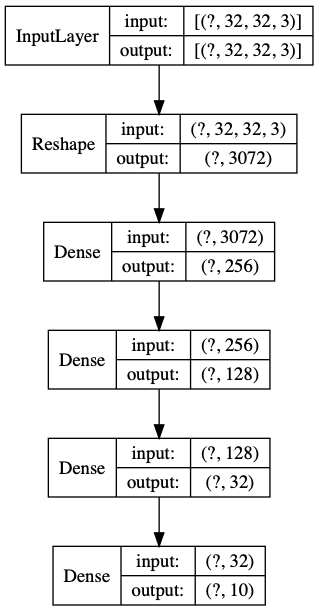

#### Answer 1.2, Preprocess (2p)

- Convert images to greyscale, other preprocessing optional.
  - Input shape should be (32,32,1)
- Explain design decisions. Is it better? Why (not)?
  - Color information is likely not so useful for classification. Greyscale makes the network smaller, less parameters to learn, less likely to overfit.

[output not shown]

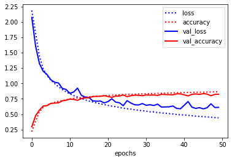

```
Model: "sequential_9"
_________________________________________________________________
Layer (type)                 Output Shape              Param #
=================================================================
reshape_9 (Reshape)          (None, 1024)              0
_________________________________________________________________
dense_36 (Dense)             (None, 256)               262400
_________________________________________________________________
dense_37 (Dense)             (None, 128)               32896
_________________________________________________________________
dense_38 (Dense)             (None, 32)                4128
_________________________________________________________________
dense_39 (Dense)             (None, 10)                330
=================================================================
Total params: 299,754
Trainable params: 299,754
Non-trainable params: 0
_________________________________________________________________
None
def build_model_1_2():
    model = models.Sequential()
    model.add(layers.Reshape((1024,), input_shape=(32,32,1)))
    model.add(layers.Dense(256, activation='relu'))
    model.add(layers.Dense(128, activation='relu'))
    model.add(layers.Dense(32, activation='relu'))
    model.add(layers.Dense(10, activation='softmax'))
    model.compile(optimizer='sgd',
                  loss='categorical_crossentropy',
                  metrics=['accuracy'])
    return model
```

#### Answer 1.3, Tune (4p)

- Regularize the model. What works best?
  - Should consider batch normalization, dropout, l1/l2 regularization (or Nesterov)
- Tune other hyperparameters (e.g. learning rate, batch size,...) as you see fit.
  - At least consider tuning learning rate, ideally also momentum, decay, other optimizers
- Explain your findings and final design decisions. Discuss the results.
  - Should be better, at least it shouldn't overfit

[output not shown]

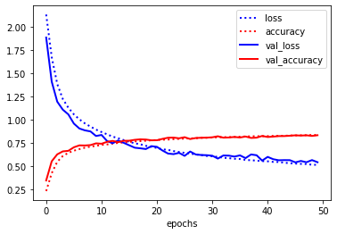

```
def build_model_1_3():
    model = models.Sequential()
    model.add(layers.Reshape((1024,), input_shape=(32,32,1)))
    model.add(layers.Dense(256, activation='relu'))
    model.add(layers.Dropout(0.05))
    model.add(layers.Dense(128, activation='relu'))
    model.add(layers.Dropout(0.05))
    model.add(layers.Dense(32, activation='relu'))
    model.add(layers.Dropout(0.05))
    model.add(layers.Dense(10, activation='softmax'))
    model.compile(optimizer=optimizers.SGD(lr=0.01, momentum=0.3),
                  loss='categorical_crossentropy',
                  metrics=['accuracy'])
    return model
```

#### Answer 2.1, ConvNet (7p)

- Build a sequential ConvNet, get at least 90% accuracy.
  - Conv2D layers, input shape (32,32,1)
  - Consider using blocks of Conv2D layers with maxpooling in between
  - Use zero-padding in Conv2D layers because the images are small
  - At least one dense hidden layer and dense output layer (sigmoid)
  - Consider adding batch normalization, dropout
  - Consider small dropout rates in beginning, larger dropout rates later in network
  - Consider other optimizers and tuning learning rate, momentum,...
- Explain what you did and why (800 chars). Is it working well?
  - Should be quite elaborate and sensible

[output not shown]

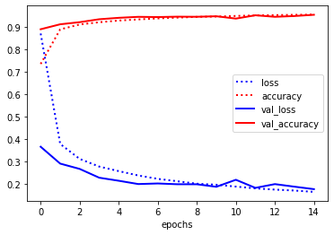

```
Model: "sequential_4"
_________________________________________________________________
Layer (type)                 Output Shape              Param #
=================================================================
conv2d_24 (Conv2D)           (None, 32, 32, 32)        320
_________________________________________________________________
batch_normalization_28 (Batc (None, 32, 32, 32)        128
_________________________________________________________________
conv2d_25 (Conv2D)           (None, 32, 32, 32)        9248
_________________________________________________________________
batch_normalization_29 (Batc (None, 32, 32, 32)        128
_________________________________________________________________
max_pooling2d_12 (MaxPooling (None, 16, 16, 32)        0
_________________________________________________________________
dropout_16 (Dropout)         (None, 16, 16, 32)        0
_________________________________________________________________
conv2d_26 (Conv2D)           (None, 16, 16, 64)        18496
_________________________________________________________________
batch_normalization_30 (Batc (None, 16, 16, 64)        256
_________________________________________________________________
conv2d_27 (Conv2D)           (None, 16, 16, 64)        36928
_________________________________________________________________
batch_normalization_31 (Batc (None, 16, 16, 64)        256
_________________________________________________________________
max_pooling2d_13 (MaxPooling (None, 8, 8, 64)          0
_________________________________________________________________
dropout_17 (Dropout)         (None, 8, 8, 64)          0
_________________________________________________________________
conv2d_28 (Conv2D)           (None, 8, 8, 128)         73856
_________________________________________________________________
batch_normalization_32 (Batc (None, 8, 8, 128)         512
_________________________________________________________________
conv2d_29 (Conv2D)           (None, 8, 8, 128)         147584
_________________________________________________________________
batch_normalization_33 (Batc (None, 8, 8, 128)         512
_________________________________________________________________
max_pooling2d_14 (MaxPooling (None, 4, 4, 128)         0
_________________________________________________________________
dropout_18 (Dropout)         (None, 4, 4, 128)         0
_________________________________________________________________
```

[output cut: 29 more lines]

```
    model.add(layers.Conv2D(128, (3, 3), activation='relu', padding='same'))
    model.add(layers.BatchNormalization())
    model.add(layers.Conv2D(128, (3, 3), activation='relu', padding='same'))
    model.add(layers.BatchNormalization())
    model.add(layers.MaxPooling2D((2, 2)))
    model.add(layers.Dropout(0.5))
    model.add(layers.Flatten())
    model.add(layers.Dense(128, activation='relu'))
    model.add(layers.BatchNormalization())
    model.add(layers.Dropout(0.5))
    model.add(layers.Dense(10, activation='softmax'))
    model.compile(optimizer='rmsprop',
                  loss='categorical_crossentropy',
                  metrics=['accuracy'])
    return model
```

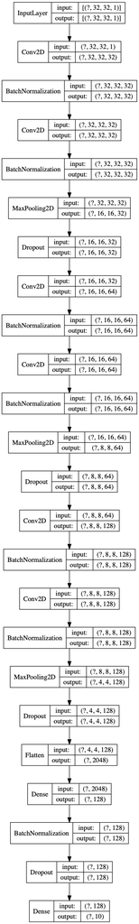

#### Answer 2.2, Data Augmentation (3p)

- Augment the preprocessed training data.
  - Use small variations (small shifts up-down, left-right) of flips becasue the images are small
  - Large shifts and rotations distort the image too much
- Explain what you did and why. Discuss the performance of the model.

[output not shown]

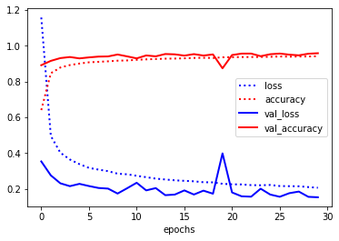

```
train_datagen = ImageDataGenerator(
    width_shift_range=0.1,
    height_shift_range=0.1,
    rotation_range=10,
    zoom_range=0.1)
```

#### Answer 3.1, Misclassifications (2p)

[output not shown]

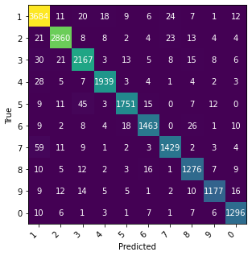

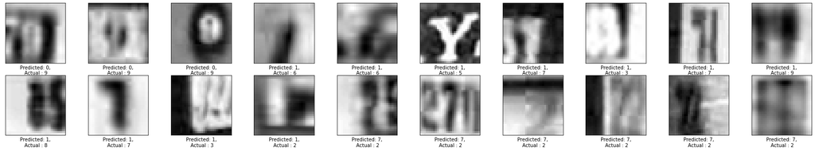

#### Answer 3.2, Activations (4p)

- Retrieve and visualize the activations for one example
- For every filter for different convolutional layers (at different depths in the network).
- Give an explanation. Is your model indeed learning something useful?
  - Should detect edges etc in first layers, higher-order object (e.g. interesting regions) in deeper layers.

[output not shown]

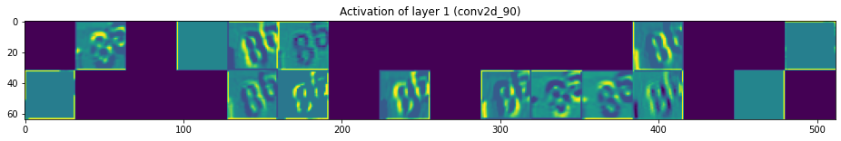

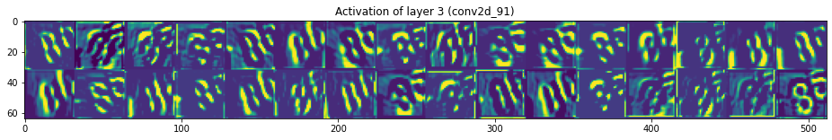

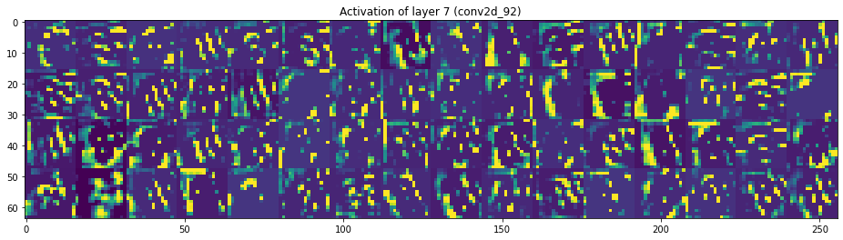

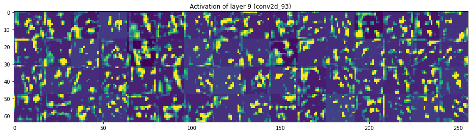

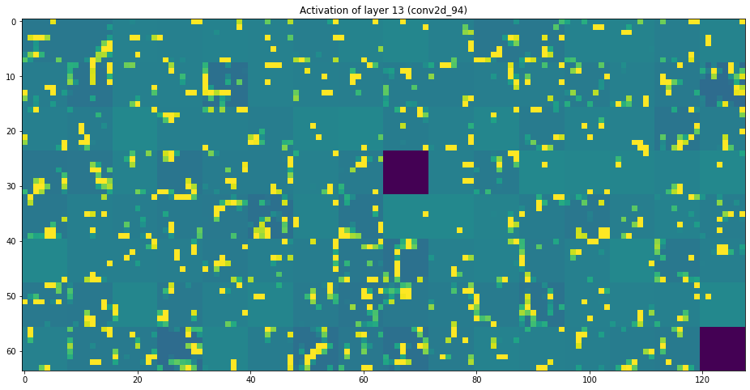

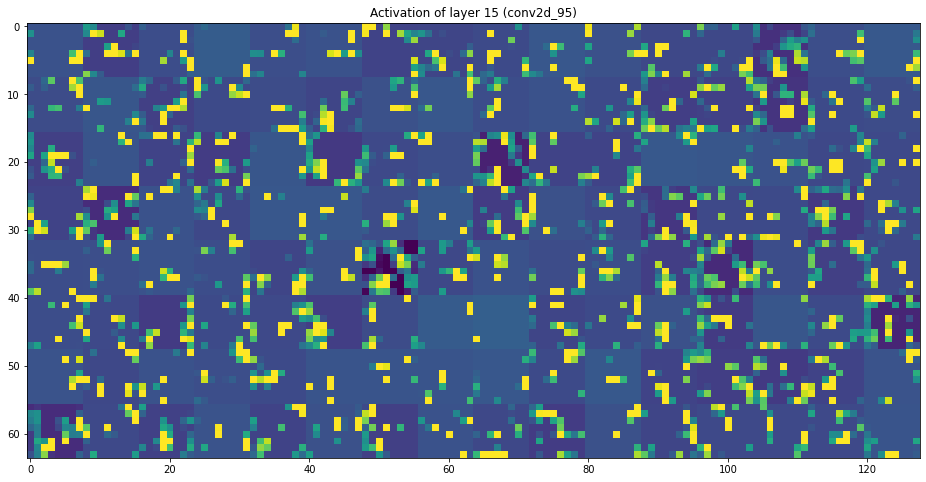

#### Answer 3.3, Class activation map (4p)

- Show a class activation map for your last convolutional layer
- Superimpose the activation map over the image, or plot side by side
  - Should make sense, detect interesting regions to classify the number

```
def plot_activation_map():
    model = load_model_from_file(base_dir, "model_2_2")

    X_test_gray = rgb2gray(X_test).astype(np.float32)
    img_tensor = X_test_gray[0]
    x = np.expand_dims(img_tensor, axis=0)

    with tf.GradientTape() as tape:
        last_conv_layer = model.get_layer('conv2d_95')
        iterate = tf.keras.models.Model([model.inputs], [model.output, last_conv_layer.output])
        model_out, last_conv_layer = iterate(x)
        class_out = model_out[:, np.argmax(model_out[0])]
        grads = tape.gradient(class_out, last_conv_layer)
        pooled_grads = K.mean(grads, axis=(0, 1, 2))
    heatmap = tf.reduce_mean(tf.multiply(pooled_grads, last_conv_layer), axis=-1)

    heatmap = np.maximum(heatmap, 0)
    heatmap /= np.max(heatmap)
    heatmap = heatmap.reshape((8, 8))

    heatmap = cv2.resize(heatmap, (img_tensor.shape[1], img_tensor.shape[0]))
    heatmap = np.uint8(255 * heatmap)
    heatmap = cv2.applyColorMap(heatmap, cv2.COLORMAP_JET)
    heatmap = cv2.cvtColor(heatmap, cv2.COLOR_BGR2RGB)

    img = heatmap * 0.1 + img_tensor

    plt.imshow(img)
```

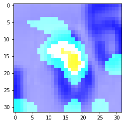

#### Answer 4.1, Fast feature extraction (5p)

- Import the VGG16 model, pretrained on ImageNet
- Freeze convolutional base, adds a dense layer
- Consider unfreezing the last few convolutional layers and evaluate whether that works better
  - Check if they do. It is very likely to help.
- Discuss the observed performance
  - Should get around 80% accuracy

[output not shown]

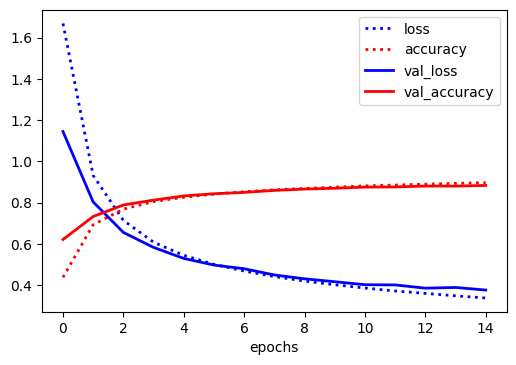

```
Model: "sequential_12"
_________________________________________________________________
Layer (type)                 Output Shape              Param #
=================================================================
vgg16 (Model)                (None, 1, 1, 512)         14714688
_________________________________________________________________
flatten_2 (Flatten)          (None, 512)               0
_________________________________________________________________
dense_44 (Dense)             (None, 128)               65664
_________________________________________________________________
dense_45 (Dense)             (None, 10)                1290
=================================================================
Total params: 14,781,642
Trainable params: 14,521,482
Non-trainable params: 260,160
_________________________________________________________________
None
def build_model_4_1():
    model = models.Sequential()
    model.add(conv_base)
    model.add(layers.Flatten())
    model.add(layers.Dense(128, activation='relu'))
    model.add(layers.Dense(10, activation='softmax'))
    model.compile(optimizer=optimizers.RMSprop(lr=1e-6),
                  loss='categorical_crossentropy',
                  metrics=['accuracy'])
    return model
```

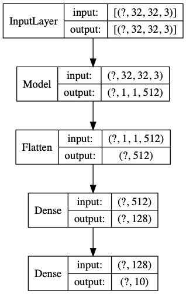

#### Answer 4.2, Embeddings (5p)

- Generate embeddings with the trained convolutional part of model_4_1 (without the dense layer)
- Embed the training and test data and store them to disk
- Build and evaluate a pipeline on the embedded data
  - Check if pipeline makes sense (e.g. use models that can handle many dimensions)
- Describe what you did and what you observed (max 800 chars).
  - Consider different models, preprocessing, tuning, etc.
  - Check performance (see original Submission.html) when in doubt. We did not run all the evaluations because it takes too long, and the output is ill-defined.

[output not shown]

```
Running time: 56.74 seconds
Last modified: May 26, 2020
scikit-learn version: 0.23.1
```